# GLM logistic demo

Kim Johnson and Joe Steensma

February 15, 2018

## Introduction. This demo will use the BRFSS.48K.csv dataset to ask and answer three questions:

1. Is BMI a risk factor for diabetes?
2. Is low income a risk factor for diabetes?
3. Are BMI and low income still risk factors after controlling for each other?

## Read in data and load libraries

```r
BRFSS<-read.csv("https://raw.githubusercontent.com/kijohnson/Advanced-Data-Analysis/master/Class%204%20Data%20Visualization/dat/BRFSS.48K.csv", header=TRUE, sep=",", na.strings=FALSE)
  BRFSS <- BRFSS[rowSums(is.na(BRFSS))==0,]
  print(head(BRFSS))
```

```
##   X_STATE EMPLOY1 INCOME2 SEATBELT DIABETE3 X_BMI5 HTM4 WTKG3 SEX X_AGE80
## 1      11       1       8        1        3   3328  165  9072   2      58
## 2      21       1       8        1        3   2663  165  7257   2      48
## 3      30       7       4        2        3     NA  168    NA   2      80
## 4      12       7       5        1        3   2806  175  8618   2      69
## 5      78       8       2        1        3   2779  165  7575   2      48
## 6      29       2       8        1        3   3034  185 10433   1      63
##   state           employed                       income      seatbelt
## 1    DC Employed for wages              $75,000 or more        Always
## 2    KY Employed for wages              $75,000 or more        Always
## 3    MT            Retired $20,000 to less than $25,000 Nearly always
## 4    FL            Retired $25,000 to less than $35,000        Always
## 5    VI     Unable to work $10,000 to less than $15,000        Always
## 6    MO      Self-employed              $75,000 or more        Always
##   diabetes diabetes_short_label    sex height weight   bmi age
## 1       No                   No Female   1.65  90.72 33.28  58
## 2       No                   No Female   1.65  72.57 26.63  48
## 3       No                   No Female   1.68     NA    NA  80
## 4       No                   No Female   1.75  86.18 28.06  69
## 5       No                   No Female   1.65  75.75 27.79  48
## 6       No                   No   Male   1.85 104.33 30.34  63
```

```r
library(plyr)
library(ggplot2)
```

## Classify diabetes as a binary variable for logistic regression analyses.

```r
class(BRFSS$diabetes)#check type of variable
```

```
## [1] "factor"
```

```r
table(BRFSS$diabetes)#look at number of observations per level
```

```
##
##                        Don't know/Not Sure
##                                         67
##                                         No
##                                      40673
##    No, pre-diabetes or borderline diabetes
##                                        931
##                                    Refused
##                                         26
##                                        Yes
##                                       6568
## Yes, but female told only during pregnancy
##                                        365
```

```r
#make a binary diabetes variable categorizing diabetes into yes and no and excluding individuals with other responses.
BRFSS$diabetes_binary[
  BRFSS$diabetes=="No"]<-0 #Assign 0 to those who responded no to the diabetes question
BRFSS$diabetes_binary[
  BRFSS$diabetes=="Yes"]<-1 #Assign 1 to those who responded yes to the diabetes question

table(BRFSS$diabetes_binary)#check to make sure re-classification worked
```

```
##
##     0     1
## 40673  6568
```

## Make a box plot to visualize whether there is a difference in the BMI distributions by diabetes status

```r
BRFSS$bmi<-as.numeric(as.character(BRFSS$bmi)) #you made need this code
```

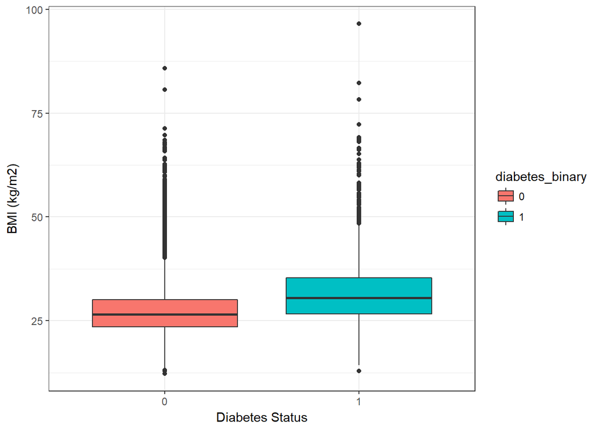

```r
BRFSS$diabetes_binary<-as.factor(BRFSS$diabetes_binary) #you made need this code

p <- ggplot(BRFSS[!is.na(BRFSS$diabetes_binary) & !is.na(BRFSS$bmi), ]) #plot and exclude NA's
  p <- p + geom_boxplot(aes(x=diabetes_binary, y=bmi, fill=diabetes_binary)) #color the boxes with fill
  p <- p + theme_bw() + xlab("Diabetes Status") + ylab("BMI (kg/m2)") #add labels to axes
  p
```

##Test assumptions of linearity, influence, and check percent correctly predicted for BMI in a logistic model

```r
#linearity
#create term to test linearity by continous variables*log(continous variable)
bmi.times.logbmi<-BRFSS$bmi*log(BRFSS$bmi)

mylogit<-glm(diabetes_binary ~ bmi + bmi.times.logbmi, data=BRFSS, family="binomial") #Box Tidwell technique, test the assumption of linearity
  summary(mylogit)
```

```
##
## Call:
## glm(formula = diabetes_binary ~ bmi + bmi.times.logbmi, family = "binomial",
##     data = BRFSS)
##
## Deviance Residuals:
##     Min       1Q   Median       3Q      Max
## -1.0699  -0.5783  -0.4561  -0.3309   3.1354
##
## Coefficients:
##                   Estimate Std. Error z value Pr(>|z|)
## (Intercept)      -11.13929    0.42098  -26.46   <2e-16 ***
## bmi                0.98846    0.05671   17.43   <2e-16 ***
## bmi.times.logbmi  -0.19729    0.01252  -15.76   <2e-16 ***
## ---
## Signif. codes:  0 '***' 0.001 '**' 0.01 '*' 0.05 '.' 0.1 ' ' 1
##
## (Dispersion parameter for binomial family taken to be 1)
##
##     Null deviance: 35147  on 43508  degrees of freedom
## Residual deviance: 32655  on 43506  degrees of freedom
##   (5121 observations deleted due to missingness)
## AIC: 32661
##
## Number of Fisher Scoring iterations: 5
```

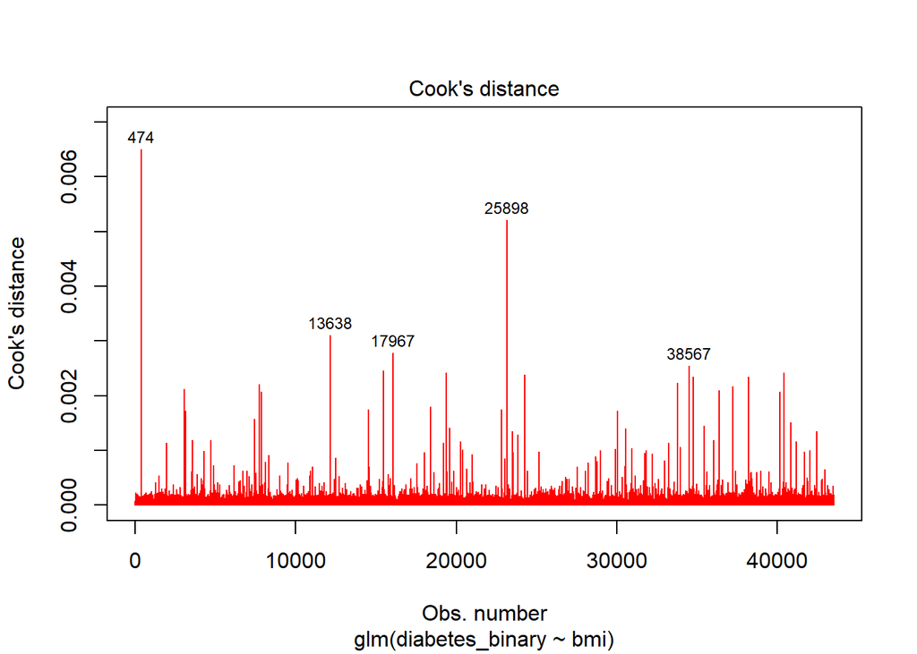

```r
# influence plots
# Cook's D plot-identifies observation number in parent dataset
mylogit2<-glm(diabetes_binary ~ bmi, data=BRFSS, family="binomial")
  plot(mylogit2, which=4, id.n=5, col="red")
```

```r
#check percent correctly predicted (example of how to do this)
xt<-table(round(predict(mylogit2, type="response")), mylogit2$model$diabetes_binary)
  xt #Note the Gold standard (reporting by participant) is the column variable and the model prediction is the row variable.
```

```
##
##         0     1
##   0 37169  5890
##   1   274   176
```

```r
     #Can you calculate sensitivity and specificity of the model for predicting diabetes?
xt2<- xt/sum(xt)
  xt2
```

```
##
##               0           1
##   0 0.854283022 0.135374290
##   1 0.006297548 0.004045140
```

```r
  p<-sum(diag(xt2))
  p #proportion of diabetes correctly classified by the model
```

```
## [1] 0.8583282
```

## Because linearity assumption was violoated with BMI, let’s create a categorical variable according to underweight (<18.5 kg/m2) normal (18.5 to <25 kg/m2), overweight (25 to <30 kg/m2), and obese (30 kg/m2 and above) categories for running in models below

```r
BRFSS$bmi_cat[
  (BRFSS$bmi>0 & BRFSS$bmi<18.5)]<-0
BRFSS$bmi_cat[
  (BRFSS$bmi>=18.5 & BRFSS$bmi<25)]<-1
BRFSS$bmi_cat[
  (BRFSS$bmi>=25 & BRFSS$bmi<30)]<-2
BRFSS$bmi_cat[
  (BRFSS$bmi>=30)]<-3

y<-table(BRFSS$bmi_cat)
  y
```

```
##
##     0     1     2     3
##   749 14288 16171 13535
```

```r
z<-sum(y)
  z
```

```
## [1] 44743
```

```r
summary(BRFSS$bmi) #determine number ofNA's bor BMI and see if the NAs plus z add up to the total number of obervations
```

```
##    Min. 1st Qu.  Median    Mean 3rd Qu.    Max.    NA's
##   12.26   23.78   27.12   28.02   31.01   96.52    3887
```

## Income modeling, first check class of the variable and numbers in each category, make a new income variable for less than 25K, 25 to <75K, >75K, exclude others from analysis

```r
class(BRFSS$income)
```

```
## [1] "factor"
```

```r
table(BRFSS$income)
```

```
##
## $10,000 to less than $15,000 $15,000 to less than $20,000
##                         2237                         3067
## $20,000 to less than $25,000 $25,000 to less than $35,000
##                         3788                         4326
## $35,000 to less than $50,000 $50,000 to less than $75,000
##                         5851                         6473
##              $75,000 or more                    < $10,000
##                        12803                         1969
##          Don't know/Not sure                           NA
##                         3568                          367
##                      Refused
##                         4181
```

```r
BRFSS$income_3L[
  BRFSS$income=="< $10,000"|
  BRFSS$income=="$10,000 to less than $15,000"|
  BRFSS$income=="$15,000 to less than $20,000"|
  BRFSS$income=="$20,000 to less than $25,000"]<-2

BRFSS$income_3L[
  BRFSS$income=="$25,000 to less than $35,000"|
  BRFSS$income=="$35,000 to less than $50,000"]<-1

BRFSS$income_3L[
  BRFSS$income=="$50,000 to less than $75,000"|
  BRFSS$income=="$75,000 or more"]<-0

y<-table(BRFSS$income_3L)#check to make sure re-classification worked
y
```

```
##
##     0     1     2
## 19276 10177 11061
```

```r
z<-sum(y)
z
```

```
## [1] 40514
```

```r
summary(BRFSS$income)
```

```
## $10,000 to less than $15,000 $15,000 to less than $20,000
##                         2237                         3067
## $20,000 to less than $25,000 $25,000 to less than $35,000
##                         3788                         4326
## $35,000 to less than $50,000 $50,000 to less than $75,000
##                         5851                         6473
##              $75,000 or more                    < $10,000
##                        12803                         1969
##          Don't know/Not sure                           NA
##                         3568                          367
##                      Refused
##                         4181
```

## Make a bivariate table and calculate proportions at each income_3L level that have diabetes (gives insight into what is expected from the model)

```r
xt<-table(BRFSS$income_3L, BRFSS$diabetes_binary)
  xt
```

```
##
##         0     1
##   0 17060  1791
##   1  8439  1441
##   2  8498  2155
```

```r
  prop.table(xt, 1)
```

```
##
##              0          1
##   0 0.90499178 0.09500822
##   1 0.85414980 0.14585020
##   2 0.79770957 0.20229043
```

## Run logistic models for both BMI, BMI_cat and income

#### BMI

```r
mylogit1<-glm(diabetes_binary ~ bmi, data=BRFSS, family="binomial")
  summary(mylogit1)
```

```
##
## Call:
## glm(formula = diabetes_binary ~ bmi, family = "binomial", data = BRFSS)
##
## Deviance Residuals:
##     Min       1Q   Median       3Q      Max
## -2.7139  -0.5492  -0.4647  -0.3865   2.6224
##
## Coefficients:
##              Estimate Std. Error z value Pr(>|z|)
## (Intercept) -4.650695   0.065002  -71.55   <2e-16 ***
## bmi          0.096806   0.002092   46.28   <2e-16 ***
## ---
## Signif. codes:  0 '***' 0.001 '**' 0.01 '*' 0.05 '.' 0.1 ' ' 1
##
## (Dispersion parameter for binomial family taken to be 1)
##
##     Null deviance: 35147  on 43508  degrees of freedom
## Residual deviance: 32921  on 43507  degrees of freedom
##   (5121 observations deleted due to missingness)
## AIC: 32925
##
## Number of Fisher Scoring iterations: 5
```

```r
  ORbmi<-exp(cbind(OR = coef(mylogit1), confint(mylogit1))) #calculate ORs and 95% CIs
  ORbmi #print ORs and 95% CIs
```

```
##                      OR       2.5 %     97.5 %
## (Intercept) 0.009554955 0.008408386 0.01084867
## bmi         1.101646482 1.097149172 1.10618263
```

#### BMI_cat

```r
mylogit2<-glm(diabetes_binary ~as.factor(bmi_cat), data=BRFSS, family="binomial")
  summary(mylogit2)
```

```
##
## Call:
## glm(formula = diabetes_binary ~ as.factor(bmi_cat), family = "binomial",
##     data = BRFSS)
##
## Deviance Residuals:
##     Min       1Q   Median       3Q      Max
## -0.7628  -0.5038  -0.5038  -0.3585   2.4682
##
## Coefficients:
##                     Estimate Std. Error z value Pr(>|z|)
## (Intercept)          -2.9972     0.1732 -17.306  < 2e-16 ***
## as.factor(bmi_cat)1   0.2848     0.1767   1.612    0.107
## as.factor(bmi_cat)2   0.9970     0.1749   5.699  1.2e-08 ***
## as.factor(bmi_cat)3   1.9113     0.1744  10.962  < 2e-16 ***
## ---
## Signif. codes:  0 '***' 0.001 '**' 0.01 '*' 0.05 '.' 0.1 ' ' 1
##
## (Dispersion parameter for binomial family taken to be 1)
##
##     Null deviance: 35147  on 43508  degrees of freedom
## Residual deviance: 33014  on 43505  degrees of freedom
##   (5121 observations deleted due to missingness)
## AIC: 33022
##
## Number of Fisher Scoring iterations: 5
```

```r
  ORbmi_cat<-exp(cbind(OR = coef(mylogit2), confint(mylogit2))) #calculate ORs and 95% CIs
  ORbmi_cat #print ORs and 95% CIs
```

```
##                             OR      2.5 %     97.5 %
## (Intercept)         0.04992867 0.03490607 0.06896991
## as.factor(bmi_cat)1 1.32945123 0.95516744 1.91332981
## as.factor(bmi_cat)2 2.71003663 1.95448526 3.88823918
## as.factor(bmi_cat)3 6.76206442 4.88278612 9.69227651
```

#### Income_3L

```r
BRFSS$income<-relevel(as.factor(BRFSS$income_3L), ref=2) #set reference at 2
  mylogit3<-glm(diabetes_binary ~ as.factor(income_3L), data=BRFSS, family="binomial")
  summary(mylogit3)
```

```
##
## Call:
## glm(formula = diabetes_binary ~ as.factor(income_3L), family = "binomial",
##     data = BRFSS)
##
## Deviance Residuals:
##     Min       1Q   Median       3Q      Max
## -0.6723  -0.5615  -0.4468  -0.4468   2.1697
##
## Coefficients:
##                       Estimate Std. Error z value Pr(>|z|)
## (Intercept)           -2.25396    0.02484  -90.76   <2e-16 ***
## as.factor(income_3L)1  0.48644    0.03781   12.87   <2e-16 ***
## as.factor(income_3L)2  0.88192    0.03462   25.48   <2e-16 ***
## ---
## Signif. codes:  0 '***' 0.001 '**' 0.01 '*' 0.05 '.' 0.1 ' ' 1
##
## (Dispersion parameter for binomial family taken to be 1)
##
##     Null deviance: 31435  on 39383  degrees of freedom
## Residual deviance: 30775  on 39381  degrees of freedom
##   (9246 observations deleted due to missingness)
## AIC: 30781
##
## Number of Fisher Scoring iterations: 4
```

```r
  ORincome<-exp(cbind(OR = coef(mylogit3), confint(mylogit3))) #calculate ORs and 95% CIs
  ORincome #print ORs and 95% CIs
```

```
##                              OR      2.5 %    97.5 %
## (Intercept)           0.1049824 0.09996163 0.1101847
## as.factor(income_3L)1 1.6265088 1.51022234 1.7514991
## as.factor(income_3L)2 2.4155385 2.25718326 2.5852991
```

## Multivariate model with diabetes as the dependent variable and income and bmi/bmi_cat as the independent variables

#### BMI continuous

```r
mylogit4<-glm(diabetes_binary ~ as.factor(income_3L) + bmi, data=BRFSS, family="binomial")
  summary(mylogit4)
```

```
##
## Call:
## glm(formula = diabetes_binary ~ as.factor(income_3L) + bmi, family = "binomial",
##     data = BRFSS)
##
## Deviance Residuals:
##     Min       1Q   Median       3Q      Max
## -2.7787  -0.5514  -0.4421  -0.3542   2.6948
##
## Coefficients:
##                        Estimate Std. Error z value Pr(>|z|)
## (Intercept)           -4.934537   0.073002  -67.59   <2e-16 ***
## as.factor(income_3L)1  0.433811   0.039725   10.92   <2e-16 ***
## as.factor(income_3L)2  0.795039   0.036682   21.67   <2e-16 ***
## bmi                    0.092971   0.002275   40.87   <2e-16 ***
## ---
## Signif. codes:  0 '***' 0.001 '**' 0.01 '*' 0.05 '.' 0.1 ' ' 1
##
## (Dispersion parameter for binomial family taken to be 1)
##
##     Null deviance: 29898  on 37379  degrees of freedom
## Residual deviance: 27515  on 37376  degrees of freedom
##   (11250 observations deleted due to missingness)
## AIC: 27523
##
## Number of Fisher Scoring iterations: 5
```

```r
  ORmodel<-exp(cbind(OR = coef(mylogit4), confint(mylogit4))) #calculate ORs and 95% CIs
  ORmodel #print ORs and 95% CIs
```

```
##                                OR       2.5 %      97.5 %
## (Intercept)           0.007193788 0.006231299 0.008295894
## as.factor(income_3L)1 1.543126487 1.427408341 1.667946498
## as.factor(income_3L)2 2.214526835 2.060972679 2.379705103
## bmi                   1.097429988 1.092559675 1.102345400
```

# BMI categorical

```r
mylogit5<-glm(diabetes_binary ~ as.factor(income_3L) + as.factor(bmi_cat), data=BRFSS, family="binomial")
  summary(mylogit5)
```

```
##
## Call:
## glm(formula = diabetes_binary ~ as.factor(income_3L) + as.factor(bmi_cat),
##     family = "binomial", data = BRFSS)
##
## Deviance Residuals:
##     Min       1Q   Median       3Q      Max
## -0.9082  -0.6236  -0.4178  -0.2901   2.7261
##
## Coefficients:
##                       Estimate Std. Error z value Pr(>|z|)
## (Intercept)           -3.69120    0.21493 -17.174  < 2e-16 ***
## as.factor(income_3L)1  0.45490    0.03960  11.487  < 2e-16 ***
## as.factor(income_3L)2  0.85560    0.03646  23.465  < 2e-16 ***
## as.factor(bmi_cat)1    0.54400    0.21693   2.508   0.0122 *
## as.factor(bmi_cat)2    1.29660    0.21514   6.027 1.67e-09 ***
## as.factor(bmi_cat)3    2.16305    0.21453  10.083  < 2e-16 ***
## ---
## Signif. codes:  0 '***' 0.001 '**' 0.01 '*' 0.05 '.' 0.1 ' ' 1
##
## (Dispersion parameter for binomial family taken to be 1)
##
##     Null deviance: 29898  on 37379  degrees of freedom
## Residual deviance: 27517  on 37374  degrees of freedom
##   (11250 observations deleted due to missingness)
## AIC: 27529
##
## Number of Fisher Scoring iterations: 5
```

```r
  ORmodel<-exp(cbind(OR = coef(mylogit5), confint(mylogit5))) #calculate ORs and 95% CIs
  ORmodel #print ORs and 95% CIs
```

```
##                             OR      2.5 %      97.5 %
## (Intercept)           0.024942 0.01590993  0.03709875
## as.factor(income_3L)1 1.576009 1.45818900  1.70308913
## as.factor(income_3L)2 2.352796 2.19062703  2.52723834
## as.factor(bmi_cat)1   1.722892 1.15315230  2.71023382
## as.factor(bmi_cat)2   3.656847 2.45731876  5.73486123
## as.factor(bmi_cat)3   8.697619 5.85254535 13.62571863
```

## Look at influential observations and percent correctly classified for whole model

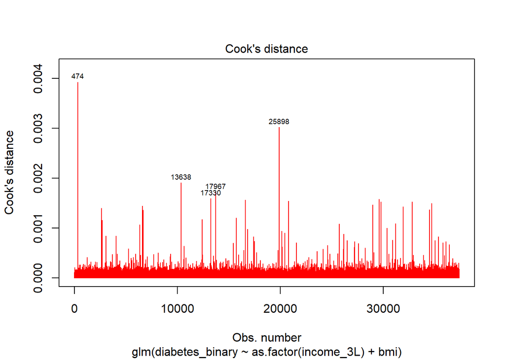

```r
#Cook's D plot
plot(mylogit4, which=4, id.n=5, col="red", cex.id=0.60)
```

```r
#identify observations with a Cook's D greater than 0.0015
y<-as.data.frame(cooks.distance(mylogit4))
colnames(y)[1]<-"CD"
y$obs_no<-rownames(y)
z<-y[which(y$CD>0.0015),]
z$obs_no
```

```
##  [1] "474"   "13638" "17330" "17967" "21625" "25898" "27151" "38567"
##  [9] "38825" "42674"
```

```r
#which(y$cooks.distance(mylogit4)>0.0015)]

#Classification
xt<-table(round(predict(mylogit4, type="response")), mylogit4$model$diabetes_binary)
  xt
```

```
##
##         0     1
##   0 31970  4939
##   1   280   191
```

```r
  xt2<- xt/sum(xt)
  xt2
```

```
##
##               0           1
##   0 0.855270198 0.132129481
##   1 0.007490637 0.005109684
```

```r
  p<-sum(diag(xt2))
  p
```

```
## [1] 0.8603799
```

## Exclude influential observations and compare Betas

```r
library(car)#car library needed for compareCoefs (notice the Camelcase!)
  mylogit.modex<-update(mylogit4,subset=c(-474, -13638, -17330, -17967, -21625, -25898, -27151, -38567, -42674))#dropping obs with CD>0.0015
  compareCoefs(mylogit4, mylogit.modex) #compare coefficients between models with and without influential         observations
```

```
##
## Call:
## 1: glm(formula = diabetes_binary ~ as.factor(income_3L) + bmi, family =
##    "binomial", data = BRFSS)
## 2: glm(formula = diabetes_binary ~ as.factor(income_3L) + bmi, family =
##    "binomial", data = BRFSS, subset = c(-474, -13638, -17330, -17967,
##   -21625, -25898, -27151, -38567, -42674))
##                         Est. 1     SE 1   Est. 2     SE 2
## (Intercept)           -4.93454  0.07300 -4.98679  0.07344
## as.factor(income_3L)1  0.43381  0.03973  0.43475  0.03975
## as.factor(income_3L)2  0.79504  0.03668  0.79625  0.03671
## bmi                    0.09297  0.00227  0.09473  0.00229
```

## Interpretation and conclusions (Discussion)

## For fun:

1. The BMI linearity assumption was violated, if you remove influential observations is it still violated using the Box Tidwell method?
2. Calculate the sensitivity and specificity of the model for predicting reported diabetes